# Madagascar Influenza — Phylogenetic Analysis

IQ-TREE ML trees · Monophyletic clade analysis

Author

Camila Duitama

Published

April 23, 2026

← Back to main report

## 1 Pipeline

**10 maximum-likelihood trees** have been built across HA and NA segments for all subtypes with ≥ 10 Madagascar and ≥ 20 other African sequences. All sequences are used — **no subsampling**.

| Category | Segments | Strategy | Trees |
| --- | --- | --- | --- |
| HA per-subtype | HA | One tree per HA subtype | 5 |
| NA per-subtype | NA | One tree per NA subtype | 5 |
| **Total (current)** |  |  | **10** |

**Tree naming:** each tree is named `<segment>_<subtype>`. For example, `HA_B` means the **Hemagglutinin (HA) gene segment** of **Influenza B** viruses; `NA_H3N2` means the **Neuraminidase (NA) gene segment** of **H3N2** viruses. HA and NA are the two surface proteins that determine subtype (the H and N numbers) and are the main targets of the immune response.

### 1.1 IQ-TREE parameters

Each tree was built with **IQ-TREE 3.1.0** using the following command:

```bash
iqtree3 -s <alignment.fasta> \
        -m HKY+G          \ # substitution model: HKY (transitions ≠ transversions) + Gamma rate variation
        -B 1000           \ # ultrafast bootstrap (UFBoot2): 1000 replicates, values shown as node labels
        -T <N_CPUs>       \ # multi-threading
        --seed 42         \ # reproducibility
        --prefix <NAME>   \ # output prefix
        --redo               # overwrite existing run
```

| Parameter | Value | Meaning |
| --- | --- | --- |
| `-m HKY+G` | HKY + Gamma | 2-parameter nucleotide model (κ for ts/tv ratio) with 4 discrete rate categories |
| `-B 1000` | UFBoot2 | Ultrafast bootstrap approximation; node support values are bootstrap percentages |
| `--seed 42` | 42 | Fixed random seed for reproducibility |

**Branch support:** node labels are UFBoot2 percentages (0–100). Values ≥ 95 are considered strongly supported.

**No subsampling:** all Africa sequences (Madagascar + rest of Africa) with the relevant segment enter the alignment directly. IQ-TREE internally deduplicates identical sequences for the ML optimisation, but adds them back as tips in the final tree — so **every input sequence appears in the treefile**.

### 1.2 Tree rooting

IQ-TREE outputs unrooted trees (no `-o` outgroup was specified). Before any clade detection, each tree is **midpoint-rooted**: the root is placed at the midpoint of the longest tip-to-tip path in the tree. This is implemented via ete3’s `get_midpoint_outgroup()` / `set_outgroup()` and is a standard approach when no outgroup sequence is available.

### 1.3 Clade detection

Before looking for Madagascar-only groups, every tree branch with UFBoot2 support **< 70** is collapsed.

A **monophyletic Madagascar clade** is then defined as the largest group of tree tips (≥ 2) that are all exclusively from Madagascar and share a common ancestor not shared with any non-Madagascar sequence.

## 2 Statistics computed per tree

| Metric | Meaning |
| --- | --- |
| `n_mdg_clades` | Number of monophyletic Madagascar clades (≥ 2 tips) |
| `mdg_pd_fraction` | What fraction of the tree’s total branch length is “owned” by Madagascar sequences (see below) |
| `mrca_subtree_fraction` | How much of the tree sits inside the subtree that spans all Madagascar sequences (see below) |

**`mdg_pd_fraction` — how much of the tree’s evolutionary space do Madagascar sequences cover?**

Imagine the tree as a road map: every branch is a road segment with a length equal to the number of mutations along that branch. Faith’s Phylogenetic Diversity (PD) for Madagascar is the total length of all roads you need to drive to visit every Madagascar sequence starting from the root. If Madagascar sequences are scattered all over the tree, you need to drive almost the entire map — high PD fraction. If they all cluster in one corner, you only need a short detour — low PD fraction. This metric is divided by the total map length so it becomes a percentage of the whole tree.

**`mrca_subtree_fraction` — how spread out are Madagascar sequences across the tree?**

The **MRCA (Most Recent Common Ancestor)** of all Madagascar sequences is the single node in the tree that is the common ancestor of every Madagascar tip. It is essentially the point where all Madagascar lineages diverge. The subtree *below* that node contains everything nested between Madagascar sequences — including non-Madagascar sequences that happen to sit among them. `mrca_subtree_fraction` is the branch-length sum of that whole subtree divided by the total tree length.

## 3 Statistics computed per clade

| Metric | Meaning |
| --- | --- |
| `internal_bl` | Sum of branch lengths within the clade — within-Madagascar diversity |
| `stem_bl` | Branch from clade root to parent — divergence from nearest African ancestor |
| `clade_prop_tree_bl` | `internal_bl` ÷ total tree branch length — clade’s share of total tree diversity |

**Note**

Results are based on **10 maximum-likelihood trees** (5 HA + 5 NA, full Africa sequences, no subsampling, UFBoot2 1000 replicates).

## 4 Input data coverage

For each tree, **every** Africa sequence with the relevant segment was used — no subsampling. IQ-TREE removes sequences that are 100% identical during the ML tree search (to save computation), but adds them back as tips in the final tree — so the treefile contains all input sequences and no sequence is truly excluded. The difference between GISAID isolate counts and tree tips reflects isolates that exist in GISAID but for which the relevant gene segment (HA or NA) was never sequenced or was not included in the GISAID download.

Table 1: Input sequences per tree. *Tips in tree* = all sequences provided as input (IQ-TREE re-attaches identical sequences at the end, so none are lost). *GISAID isolates* = total Africa isolates with this subtype in metadata. *Missing segment* = isolates in GISAID that do not have this gene segment sequenced.

| Tree | Tips in tree | Madagascar | Other Africa | % Madagascar | GISAID isolates¹ | Missing segment² | % missing² |
| --- | --- | --- | --- | --- | --- | --- | --- |
| HA_B | 5,015 | 365 | 4,650 | 7.3% | 5,081 | 66 | 1.3% |
| HA_H1N1 | 8,621 | 234 | 8,387 | 2.7% | 9,449 | 828 | 8.8% |
| HA_H3N2 | 9,587 | 375 | 9,212 | 3.9% | 10,004 | 417 | 4.2% |
| HA_H6N2 | 64 | 27 | 37 | 42.2% | 67 | 3 | 4.5% |
| HA_H9N2 | 1,268 | 51 | 1,217 | 4.0% | 1,444 | 176 | 12.2% |
| NA_B | 3,668 | 258 | 3,410 | 7.0% | 5,081 | 1,413 | 27.8% |
| NA_H1N1 | 7,959 | 203 | 7,756 | 2.6% | 9,449 | 1,490 | 15.8% |
| NA_H3N2 | 8,965 | 369 | 8,596 | 4.1% | 10,004 | 1,039 | 10.4% |
| NA_H6N2 | 65 | 28 | 37 | 43.1% | 67 | 2 | 3.0% |
| NA_H9N2 | 868 | 53 | 815 | 6.1% | 1,444 | 576 | 39.9% |

¹ Total GISAID Africa isolates with this subtype (all hosts, from `combined_metadata.tsv`).  
² Isolates in GISAID that do not have the relevant gene segment (HA or NA) sequenced; these were not part of any tree.

*Trees range from 64 (HA_H6N2) to 9,587 (HA_H3N2) sequences; Madagascar sequences account for 2.6–43.1% of each tree.*

## 5 Clade analysis results

### 5.1 Summary per tree

Table 2: Per-tree clade statistics. Only groupings with at least 70% bootstrap support were counted as clades; weaker groupings were treated as unresolved. **Mdg seqs**: total Madagascar sequences in the tree. **Africa seqs**: total non-Madagascar African sequences. **Clades**: number of monophyletic Madagascar-only groups (≥ 2 sequences). **Singletons**: Madagascar sequences not assigned to any clade. **% Mdg in clades**: percentage of Madagascar sequences that fall inside a clade. **Mdg PD %**: fraction of total tree phylogenetic diversity attributable to Madagascar sequences. **MRCA frac**: fraction of the tree spanned by the subtree rooted at the most recent common ancestor of all Madagascar sequences (1 = spans the whole tree). **Mean clade size**: average number of Madagascar sequences per clade. **Mean stem BL**: average length of the branch leading into each Madagascar clade (longer = more diverged from non-Madagascar relatives).

| Tree | Mdg seqs | Africa seqs | Clades | Singletons | % Mdg in clades | Mdg PD % | MRCA frac | Mean clade size | Mean stem BL |
| --- | --- | --- | --- | --- | --- | --- | --- | --- | --- |
| HA_B | 365 | 4650 | 57 | 110 | 69.9% | 3.7% | 1.000 | 4.5 | 0.0009 |
| HA_H1N1 | 234 | 8387 | 36 | 100 | 57.3% | 2.0% | 1.000 | 3.7 | 0.0061 |
| HA_H3N2 | 375 | 9212 | 25 | 63 | 83.2% | 2.8% | 1.000 | 12.5 | 0.0035 |
| HA_H6N2 | 27 | 37 | 1 | 1 | 96.3% | 11.4% | 0.215 | 26.0 | 0.0313 |
| HA_H9N2 | 51 | 1217 | 2 | 0 | 100.0% | 1.8% | 0.714 | 25.5 | 0.0240 |
| NA_B | 258 | 3410 | 31 | 93 | 64.0% | 3.9% | 1.000 | 5.3 | 0.0010 |
| NA_H1N1 | 203 | 7756 | 29 | 95 | 53.2% | 1.8% | 0.694 | 3.7 | 0.0063 |
| NA_H3N2 | 369 | 8596 | 37 | 120 | 67.5% | 1.8% | 0.507 | 6.7 | 0.0012 |
| NA_H6N2 | 28 | 37 | 2 | 0 | 100.0% | 20.4% | 0.292 | 14.0 | 0.0179 |
| NA_H9N2 | 53 | 815 | 2 | 0 | 100.0% | 1.6% | 0.027 | 26.5 | 0.0216 |
| **Mean ± SD** | 196.3 ± 146.9 | 4411.7 ± 3800.8 | 22.2 ± 19.5 | 58.2 ± 51.9 | 79.1 ± 18.9% | 5.1 ± 6.1% | 0.645 ± 0.369 | 12.8 ± 9.7 | 0.0114 ± 0.0113 |

*Across the 10 trees, Madagascar sequences form 22.2 ± 19.5 clades per tree on average, grouping 79% of sequences; MRCA fraction ranges from 0.027 (NA_H9N2) to 1.000 (HA_B), spanning tight local clustering to broad seasonal spread.*

## 6 Tree visualisation

### 6.1 ete3 circular plots

#### 6.1.1 HA_H6N2

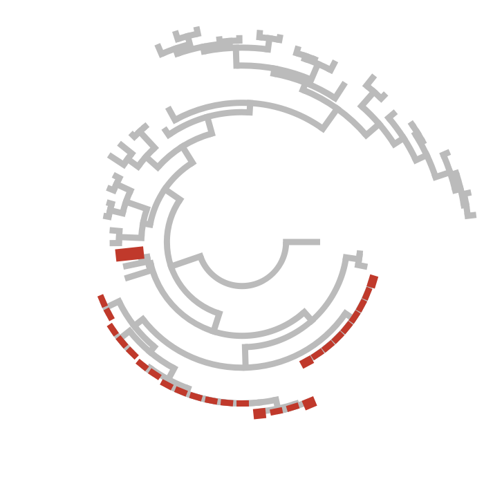

Figure 1: HA_H6N2 — full tree (64 tips: 27 Madagascar in red, 37 other Africa in grey).

#### 6.1.2 NA_H6N2

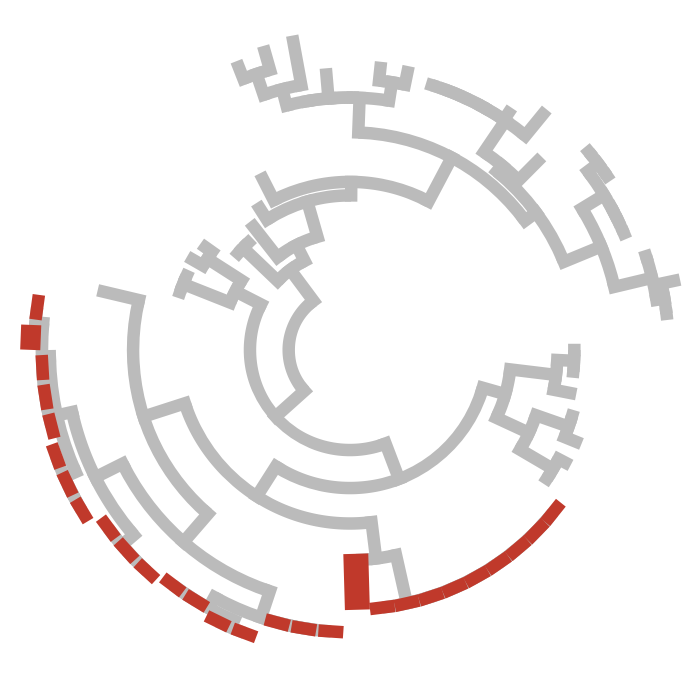

Figure 2: NA_H6N2 — full tree (65 tips: 28 Madagascar in red, 37 other Africa in grey).